# Project - Linear Regression

Peter

February 24, 2019

```r
library(ggplot2)
library(dplyr)
library(caTools)

bike <- read.csv('bikeshare.csv')
head(bike)
```

```
##              datetime season holiday workingday weather temp  atemp
## 1 2011-01-01 00:00:00      1       0          0       1 9.84 14.395
## 2 2011-01-01 01:00:00      1       0          0       1 9.02 13.635
## 3 2011-01-01 02:00:00      1       0          0       1 9.02 13.635
## 4 2011-01-01 03:00:00      1       0          0       1 9.84 14.395
## 5 2011-01-01 04:00:00      1       0          0       1 9.84 14.395
## 6 2011-01-01 05:00:00      1       0          0       2 9.84 12.880
##   humidity windspeed casual registered count
## 1       81    0.0000      3         13    16
## 2       80    0.0000      8         32    40
## 3       80    0.0000      5         27    32
## 4       75    0.0000      3         10    13
## 5       75    0.0000      0          1     1
## 6       75    6.0032      0          1     1
```

```r
any(is.na(bike))
```

```
## [1] FALSE
```

```r
str(bike)
```

```
## 'data.frame':    10886 obs. of  12 variables:
##  $ datetime  : Factor w/ 10886 levels "2011-01-01 00:00:00",..: 1 2 3 4 5 6 7 8 9 10 ...
##  $ season    : int  1 1 1 1 1 1 1 1 1 1 ...
##  $ holiday   : int  0 0 0 0 0 0 0 0 0 0 ...
##  $ workingday: int  0 0 0 0 0 0 0 0 0 0 ...
##  $ weather   : int  1 1 1 1 1 2 1 1 1 1 ...
##  $ temp      : num  9.84 9.02 9.02 9.84 9.84 ...
##  $ atemp     : num  14.4 13.6 13.6 14.4 14.4 ...
##  $ humidity  : int  81 80 80 75 75 75 80 86 75 76 ...
##  $ windspeed : num  0 0 0 0 0 ...
##  $ casual    : int  3 8 5 3 0 0 2 1 1 8 ...
##  $ registered: int  13 32 27 10 1 1 0 2 7 6 ...
##  $ count     : int  16 40 32 13 1 1 2 3 8 14 ...
```

We are going to predict the count (total rentals per hour)

# Exploratory Data Analysis

## Scatterplot, temp v count

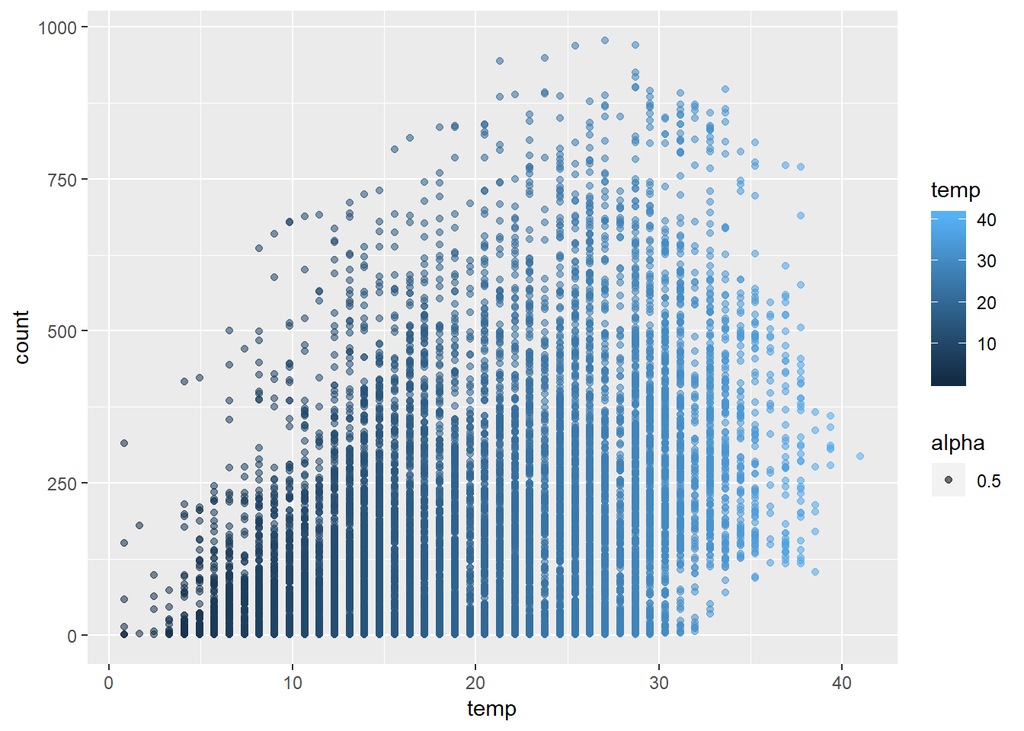

```r
pl <- ggplot(data=bike, aes(x=temp,y=count))
pl + geom_point(aes(color=temp,alpha=0.5))
```

As temperature goes up, the number of total rentals also go up.

## Scatterplot, datetime v count

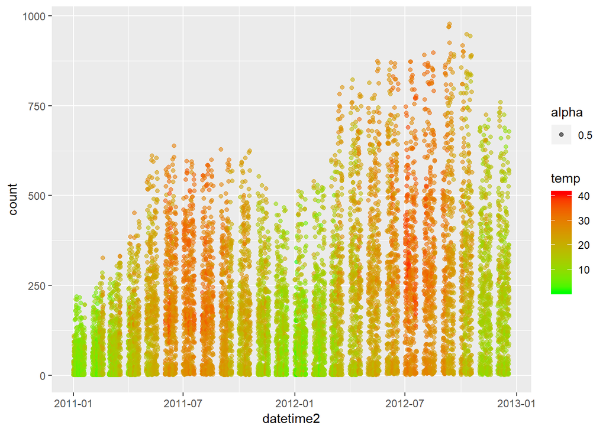

```r
bike$datetime2 <- as.POSIXct(bike$datetime)
pl2 <- ggplot(data=bike,aes(x=datetime2,y=count))
pl2 + geom_point(aes(color=temp, alpha=0.5)) + scale_color_gradient(low='green',high='red')
```

Summer months get more total rentals, but also total rentals increase year to year.

## Correlation, temp v count

```r
cor(x=bike$temp,y=bike$count)
```

```
## [1] 0.3944536
```

Temperature and total bike rentals are positively but loosely correlated. As seen in the first scatterplot.

## Boxplot, seasons v count

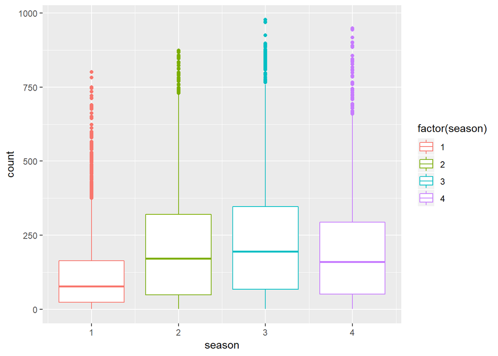

```r
pl3 <- ggplot(data=bike,aes(x=season,y=count))
pl3 + geom_boxplot(aes(color=factor(season)))
```

For interpretation of boxplots checkout [this](https://www.mathbootcamps.com/how-to-read-a-boxplot/) guide.

Seasons 1=spring, 2=summer, 3=fall, 4=winter

| Spring | Summer | Fall | Winter |  |
| --- | --- | --- | --- | --- |
| 50% of the seasons had around 100 rentals | 50% of the season had around 150 rentals | 50% of the season had around 175 rentals | 50% of the season had around 140 rentals |  |

There is a lot of variance in total rental sales per season. Likely due to temperature, weekday v weekend, etc.

# Feature Engineering

## Using normal functions

```r
hours <- function(x){
  time.stamp <- x
  format(time.stamp, "%H")
}
bike$hours <- lapply(bike$datetime2,hours)
```

## Using anonymous function

```r
bike$hours <- lapply(bike$datetime2, function(x){format(time.stamp<-x,"%H")})
head(bike)
```

```
##              datetime season holiday workingday weather temp  atemp
## 1 2011-01-01 00:00:00      1       0          0       1 9.84 14.395
## 2 2011-01-01 01:00:00      1       0          0       1 9.02 13.635
## 3 2011-01-01 02:00:00      1       0          0       1 9.02 13.635
## 4 2011-01-01 03:00:00      1       0          0       1 9.84 14.395
## 5 2011-01-01 04:00:00      1       0          0       1 9.84 14.395
## 6 2011-01-01 05:00:00      1       0          0       2 9.84 12.880
##   humidity windspeed casual registered count           datetime2 hours
## 1       81    0.0000      3         13    16 2011-01-01 00:00:00    00
## 2       80    0.0000      8         32    40 2011-01-01 01:00:00    01
## 3       80    0.0000      5         27    32 2011-01-01 02:00:00    02
## 4       75    0.0000      3         10    13 2011-01-01 03:00:00    03
## 5       75    0.0000      0          1     1 2011-01-01 04:00:00    04
## 6       75    6.0032      0          1     1 2011-01-01 05:00:00    05
```

We extracted the hours from the datetime in order to be able to create the scatterplots below.

## Scatterplot, hour v count

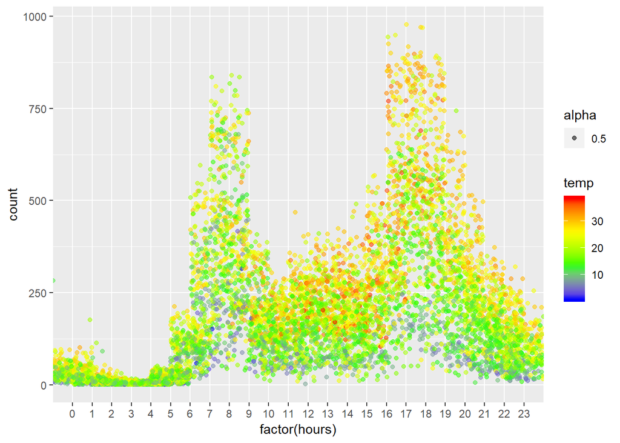

```r
bike$hours <- as.integer(bike$hours)
bike.work <- filter(bike,workingday==1)
pl4 <- ggplot(data=bike.work,aes(x=factor(hours),y=count))
pl4 + geom_point(aes(color=temp, alpha=0.5),position = position_jitter(w=1,h=0)) + scale_color_gradientn(colors=c('blue','green','yellow','red'))
```

During the weekdays, peak total rentals occurred between 7-9am and 4-8pm. During higher temperatures there were more rentals.

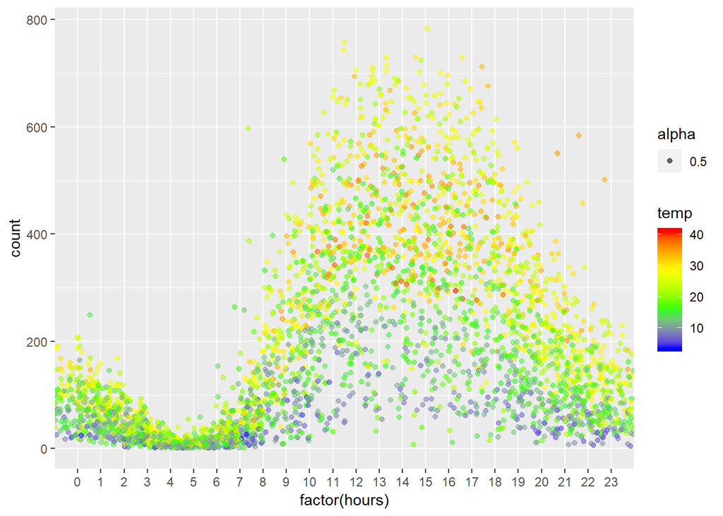

```r
bike.nonwork <- filter(bike,workingday==0)
pl5 <- ggplot(bike.nonwork,aes(x=factor(hours),y=count))
pl5 + geom_point(aes(color=temp, alpha=0.5),position = position_jitter(w=1,h=0)) + scale_color_gradientn(colors=c('blue','green','yellow','red'))
```

During the weekends, there were high amount of rentals throughout the day. During higher temperatures there were more rentals.

# Building the Model 1

```r
temp.model <- lm(count~temp,data=bike)
summary(temp.model)
```

```
##
## Call:
## lm(formula = count ~ temp, data = bike)
##
## Residuals:
##     Min      1Q  Median      3Q     Max
## -293.32 -112.36  -33.36   78.98  741.44
##
## Coefficients:
##             Estimate Std. Error t value Pr(>|t|)
## (Intercept)   6.0462     4.4394   1.362    0.173
## temp          9.1705     0.2048  44.783   <2e-16 ***
## ---
## Signif. codes:  0 '***' 0.001 '**' 0.01 '*' 0.05 '.' 0.1 ' ' 1
##
## Residual standard error: 166.5 on 10884 degrees of freedom
## Multiple R-squared:  0.1556, Adjusted R-squared:  0.1555
## F-statistic:  2006 on 1 and 10884 DF,  p-value: < 2.2e-16
```

```r
predict(temp.model,data.frame(temp=25))
```

```
##        1
## 235.3097
```

Temperature only explains 15% of variability in total bike rentals. Our model predicts with 15% certainty that 235 bike rentals will occur when the temperature is 25C.

# Building the Model 2

```r
bike$num.hours <- sapply(bike$hours, function(x){as.numeric(x)})
all.model <- lm(count~. -datetime-atemp-casual-registered-count-datetime2-hours,data=bike)
summary(all.model)
```

```
##
## Call:
## lm(formula = count ~ . - datetime - atemp - casual - registered -
##     count - datetime2 - hours, data = bike)
##
## Residuals:
##     Min      1Q  Median      3Q     Max
## -324.61  -96.88  -31.01   55.27  688.83
##
## Coefficients:
##              Estimate Std. Error t value Pr(>|t|)
## (Intercept)  46.91369    8.45147   5.551 2.91e-08 ***
## season       21.70333    1.35409  16.028  < 2e-16 ***
## holiday     -10.29914    8.79069  -1.172    0.241
## workingday   -0.71781    3.14463  -0.228    0.819
## weather      -3.20909    2.49731  -1.285    0.199
## temp          7.01953    0.19135  36.684  < 2e-16 ***
## humidity     -2.21174    0.09083 -24.349  < 2e-16 ***
## windspeed     0.20271    0.18639   1.088    0.277
## num.hours     7.61283    0.21688  35.102  < 2e-16 ***
## ---
## Signif. codes:  0 '***' 0.001 '**' 0.01 '*' 0.05 '.' 0.1 ' ' 1
##
## Residual standard error: 147.8 on 10877 degrees of freedom
## Multiple R-squared:  0.3344, Adjusted R-squared:  0.3339
## F-statistic:   683 on 8 and 10877 DF,  p-value: < 2.2e-16
```

This data does not fit a lm very well, even though p<0.0001. R^2 = 0.33.

## Problems with the Linear Model

### Nonlinearity

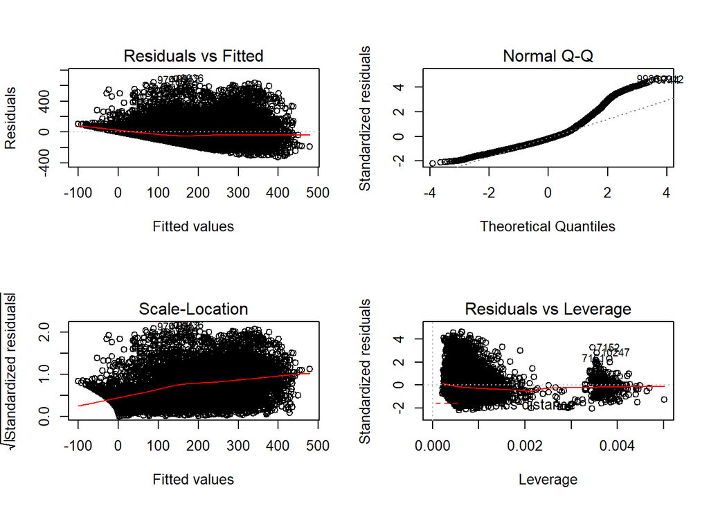

```r
par(mfrow=c(2,2))
plot(all.model)
```

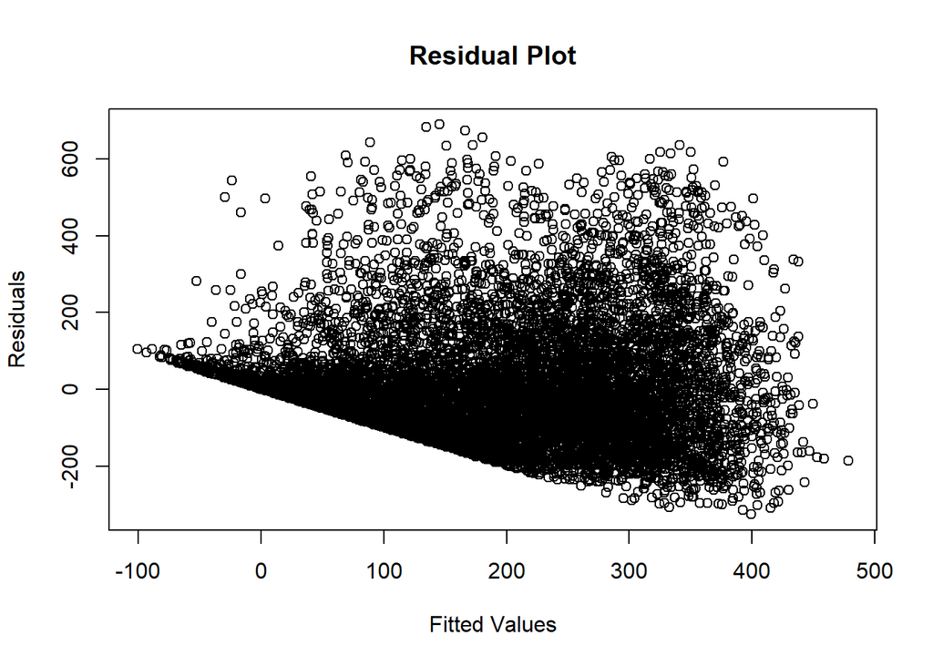

```r
plot(x=predict(all.model), y=residuals(all.model),
     xlab = 'Fitted Values',
     ylab = 'Residuals',
     main = 'Residual Plot')
```

- There is a clear pattern in residuals, the linear model is thus not a good fit.

### Correlation of error terms

- Not sure how to show whether or not tracking appears in the residuals.

### Non-constant variance of error terms

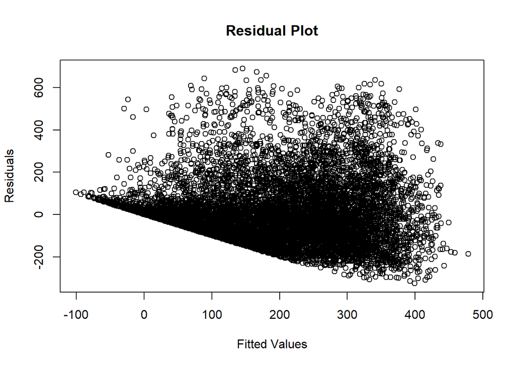

```r
plot(x=predict(all.model), y=residuals(all.model),
     xlab = 'Fitted Values',
     ylab = 'Residuals',
     main = 'Residual Plot')
```

- Residual plot indicates heteroscedasticity, so the error terms have non-constant variance from the regression line.

### Outliers

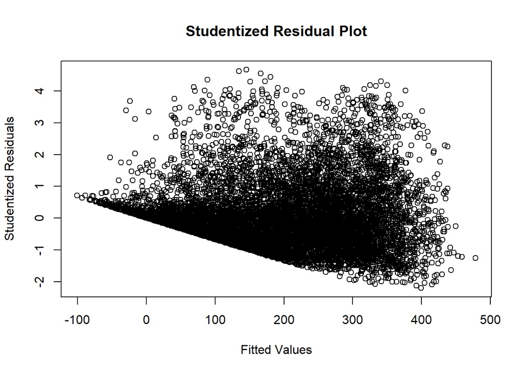

```r
plot(x=predict(all.model), y=rstudent(all.model),
     xlab = 'Fitted Values',
     ylab = 'Studentized Residuals',
     main = 'Studentized Residual Plot')
```

- Residual plot shows no clear outliers
- Studentized residual plot shows lots of ‘possible outliers’ as their stundentized residual > 3

### High-leverage points

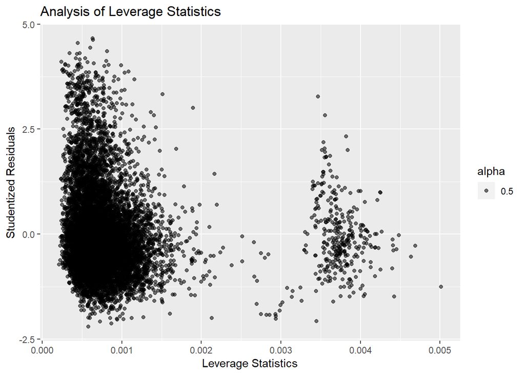

```r
pl6 <- ggplot(bike,aes(x=hatvalues(all.model),y=rstudent(all.model)))
pl6 + geom_point(aes(alpha=0.5)) +
  xlab('Leverage Statistics') +
  ylab('Studentized Residuals') +
  ggtitle('Analysis of Leverage Statistics')
```

- Plot shows some observations with outlying leverages that are still well below 1, and no real high-leverage points.

```r
max(hatvalues(all.model))
```

```
## [1] 0.00501235
```

- The maximum leverage statistic is 0.005, not indicating a high-leverage point.

### Collinearity

```r
library(car) # has vif function
vif(all.model)
```

```
##     season    holiday workingday    weather       temp   humidity
##   1.137577   1.068101   1.070116   1.247738   1.106968   1.521792
##  windspeed  num.hours
##   1.153230   1.120304
```

- VIF values > 5 or 10 would indicate too much collinearity
- All observed VIF values are ~1, indicating no collinearity

## Steps in linear regression analysis:

```r
summary(all.model)
```

```
##
## Call:
## lm(formula = count ~ . - datetime - atemp - casual - registered -
##     count - datetime2 - hours, data = bike)
##
## Residuals:
##     Min      1Q  Median      3Q     Max
## -324.61  -96.88  -31.01   55.27  688.83
##
## Coefficients:
##              Estimate Std. Error t value Pr(>|t|)
## (Intercept)  46.91369    8.45147   5.551 2.91e-08 ***
## season       21.70333    1.35409  16.028  < 2e-16 ***
## holiday     -10.29914    8.79069  -1.172    0.241
## workingday   -0.71781    3.14463  -0.228    0.819
## weather      -3.20909    2.49731  -1.285    0.199
## temp          7.01953    0.19135  36.684  < 2e-16 ***
## humidity     -2.21174    0.09083 -24.349  < 2e-16 ***
## windspeed     0.20271    0.18639   1.088    0.277
## num.hours     7.61283    0.21688  35.102  < 2e-16 ***
## ---
## Signif. codes:  0 '***' 0.001 '**' 0.01 '*' 0.05 '.' 0.1 ' ' 1
##
## Residual standard error: 147.8 on 10877 degrees of freedom
## Multiple R-squared:  0.3344, Adjusted R-squared:  0.3339
## F-statistic:   683 on 8 and 10877 DF,  p-value: < 2.2e-16
```

1. Our linear model is significant (F=683, p < 0.0001)
2. Variables not significantly correlated with total rental count include holiday, workingday, weather, windspeed.
3. A high RSE of 147.8 indicates lots of deviation from the linear regression line. Low R^2 of 0.33 indicates only 33% of variability in total rental count is explained by our predictors using the linear model.
4. I did not do prediction with this model.

## Conclusion

A linear model does not fit the data as evidenced by:

- Clear pattern in the residual plot
- Non-constant variance of residual error terms
- Presence of outliers
- (Error terms were not correlated)
- (There is no presence of high leverage points)
- (There is no presence of collinearity)